# Messing around with Gapminder

Let’s start with a bit of a whirlwind introduction to R using the Gapminder data. The focus of this notebook will be on doing stuff and seeing what R is capable of and developing some basic coding intuition; we will go into greater detail on the code works in later notebooks.

We will need 3 packages.

To load them into memory, use the `library()` function. If you haven’t yet installed them, use the `install.packages()` function first.

```r
install.packages("gapminder")
install.packages("stargazer")
install.packages("tidyverse")
```

Once a package is installed, it doesn’t have to be installed again.

```r
library(tidyverse)
```

Let’s see what the `gapminder` package is all about. You can get help in a couple of ways;

```r
?gapminder
help(gapminder)
```

Typing either of these commands into the R Console will result in a help file popping up in the bottom right panel of RStudio with detailed information.

Some packages have long-form help documents called a `vignette`. The `gapminder` package does not, but stargazer does.

```r
vignette("stargazer")
```

If you type this into your console, a pdf helpfile should open on your computer about `stargazer`.

## Looking at the data

The `gapminder` package includes 2 datasets. Let’s grab the main dataset.

```r
data("gapminder")
```

The `gapminder` data should now exist as an object in your environment window. You can easily look at the data by clicking on the object. The helpfile (discussed above) has some variable descriptions.

Another way to look a the data is to use the `head()` or `tail()` command - this shows you the first 6 or last 6 lines of data, which is a pretty useful trick.

```r
head(gapminder)
```

| country | continent | year | lifeExp | pop | gdpPercap |
| --- | --- | --- | --- | --- | --- |
| Afghanistan | Asia | 1952 | 28.801 | 8425333 | 779.4453 |
| Afghanistan | Asia | 1957 | 30.332 | 9240934 | 820.8530 |
| Afghanistan | Asia | 1962 | 31.997 | 10267083 | 853.1007 |
| Afghanistan | Asia | 1967 | 34.020 | 11537966 | 836.1971 |
| Afghanistan | Asia | 1972 | 36.088 | 13079460 | 739.9811 |
| Afghanistan | Asia | 1977 | 38.438 | 14880372 | 786.1134 |

```r
tail(gapminder)
```

| country | continent | year | lifeExp | pop | gdpPercap |
| --- | --- | --- | --- | --- | --- |
| Zimbabwe | Africa | 1982 | 60.363 | 7636524 | 788.8550 |
| Zimbabwe | Africa | 1987 | 62.351 | 9216418 | 706.1573 |
| Zimbabwe | Africa | 1992 | 60.377 | 10704340 | 693.4208 |
| Zimbabwe | Africa | 1997 | 46.809 | 11404948 | 792.4500 |
| Zimbabwe | Africa | 2002 | 39.989 | 11926563 | 672.0386 |
| Zimbabwe | Africa | 2007 | 43.487 | 12311143 | 469.7093 |

We can further explore the data by making a `summary()` of it:

```r
summary(gapminder)
```

[output not shown]

Another useful tool for creating tables is `stargazer()`. It’s a bit finicky in this instance, but the result is a nicely formatted table.

```r
stargazer(as.data.frame(gapminder), type="text")
```

```
===========================================================================================
Statistic   N        Mean         St. Dev.       Min   Pctl(25)    Pctl(75)        Max
-------------------------------------------------------------------------------------------
year      1,704   1,979.500        17.265       1,952   1,965.8    1,993.2        2,007
lifeExp   1,704     59.474         12.917      23.599   48.198      70.846       82.603
pop       1,704 29,601,212.000 106,157,897.000 60,011  2,793,664 19,585,222.0 1,318,683,096
gdpPercap 1,704   7,215.327       9,857.455    241.166 1,202.060  9,325.462    113,523.100
-------------------------------------------------------------------------------------------
```

We can apply functions to this dataset. Let’s find the `mean` GDP per capita.

```r
mean(gapminder$gdpPercap)
```

```
[1] 7215.327
```

Or maybe we want to know the `mean` GDP per capita in the first and last years of the dataset (1952 and 2007):

```r
mean(gapminder$gdpPercap[gapminder$year==1952])
```

```
[1] 3725.276
```

```r
mean(gapminder$gdpPercap[gapminder$year==2007])
```

```
[1] 11680.07
```

If you are feeling lazy and don’t want to have to type the name of the data set every time you refer to a variable in it, you can `attach()` it. This practice is generally frowned upon, but is a very useful crutch while learning how to use R.

```r
attach(gapminder)
mean(gdpPercap[year==1952])
```

```
[1] 3725.276
```

```r
mean(gdpPercap[year==2007])
```

```
[1] 11680.07
```

We can also graph this data. R has a bunch of inbuilt graphing utilities, but `ggplot2` is the current gold standard for displaying data. Let’s see a bit of both looking at life expectancy. the `hist()` command is included in base R.

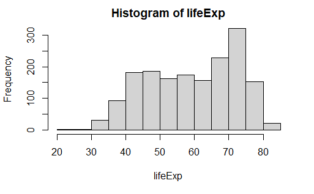

```r
hist(lifeExp)
```

If we use `ggplot()` (this is in the `tidyverse` package we already installed), we can get something much more detailed and visually appealing with just a couple extra lines of code.

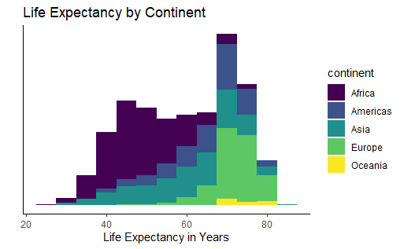

```r
ggplot(data = gapminder, aes(x = lifeExp))+
    geom_histogram(aes(fill = continent), binwidth = 5, show.legend = TRUE) +
    theme_classic() +
    theme(axis.text.y=element_blank(),
          axis.ticks.y=element_blank())+
    labs(title = "Life Expectancy by Continent", x = "Life Expectancy in Years", y = "") +
    scale_fill_viridis_d()
```

```r
NA
```

Here is a boxplot of life expectancy by continent.

```r
ggplot(data = gapminder, aes(x = continent, y = lifeExp)) +
    geom_boxplot(aes(fill = continent), show.legend = FALSE) +
    theme_classic() +
    scale_fill_viridis_d() +
    labs(y = "Life Expectancy in Years", title = "Life Expectancy by Continent", x = "")
```

[output not shown]

We will come back to doing visualizations a bit later.

## Manipulating the Data

Also included in the `tidyverse` package is a package called `dplyr`, which is indispensable for manipulating data.

The most important `dplyr` verbs to remember are:

- `select` - Selects columns
- `filter` - Filters Rows
- `arrange` - re-orders rows
- `mutate` - creates new columns
- `summarize` - summarizes stuff
- `group_by` - allows you to split-apply-recombine data along with `ungroup`

One of the most useful things to learn early in in `dplyr` is the **pipe** operator, which looks like this `%>%`.

The keyboard shortcut for `%>%` is Control-Shift-M. That’s a useful one to memorize!

The way to think about the pipe operator is that it “pipes” the results from one line of code into the next.

Let’s put some of these new tools to work. Let’s remind ourselves what our data look like:

```r
head(gapminder)
```

| country | continent | year | lifeExp | pop | gdpPercap |
| --- | --- | --- | --- | --- | --- |
| Afghanistan | Asia | 1952 | 28.801 | 8425333 | 779.4453 |
| Afghanistan | Asia | 1957 | 30.332 | 9240934 | 820.8530 |
| Afghanistan | Asia | 1962 | 31.997 | 10267083 | 853.1007 |
| Afghanistan | Asia | 1967 | 34.020 | 11537966 | 836.1971 |
| Afghanistan | Asia | 1972 | 36.088 | 13079460 | 739.9811 |
| Afghanistan | Asia | 1977 | 38.438 | 14880372 | 786.1134 |

Let’s say we are interested in looking at differences in life expectancy and GDP per capita across continents in the year 2007. Using select and filter, we can reduce the amount of data we are working with.

```r
gapminder %>%
    filter(year == 2007) %>%
    select(continent, lifeExp, gdpPercap)
```

| continent | lifeExp | gdpPercap |
| --- | --- | --- |
| Asia | 43.828 | 974.5803 |
| Europe | 76.423 | 5937.0295 |
| Africa | 72.301 | 6223.3675 |
| Africa | 42.731 | 4797.2313 |
| Americas | 75.320 | 12779.3796 |
| Oceania | 81.235 | 34435.3674 |
| Europe | 79.829 | 36126.4927 |
| Asia | 75.635 | 29796.0483 |
| Asia | 64.062 | 1391.2538 |
| Europe | 79.441 | 33692.6051 |

[output cut: 132 more lines]

This code executed the command, but maybe we want to store this subset of data in a separate object, which we can do by using <- to assign it to an object which we will call dat.

```r
dat <- gapminder %>%
    filter(year == 2007) %>%
    select(continent, lifeExp, gdpPercap)
```

Now you should have an object in your environment called dat!

```r
dat
```

[output not shown]

```r
dat %>%
    group_by(continent) %>%
    summarize(AvgIncome = median(gdpPercap))
```

| continent | AvgIncome |
| --- | --- |
| Africa | 1452.267 |
| Americas | 8948.103 |
| Asia | 4471.062 |
| Europe | 28054.066 |
| Oceania | 29810.188 |

And again for Life Expectancy:

```r
dat %>%
    group_by(continent) %>%
    summarize(AvgLifeExp = mean(lifeExp))
```

| continent | AvgLifeExp |
| --- | --- |
| Africa | 54.80604 |
| Americas | 73.60812 |
| Asia | 70.72848 |
| Europe | 77.64860 |
| Oceania | 80.71950 |

## Basic Statistics

Let’s dig a bit deeper into the Life Expectancy means. The data show that Oceania and Europe have a 3 year difference in their life expectancy. Is this difference **statistically significant**? We can test this using a concept you might be familiar with from your earlier statistics class: the 2-sample T-test.

First, we take our dataset of life expectancy from 2007 (dat), filter out everything that is not Europe and Oceania, get rid of the GDP data, and save that in a new object called dat2.

[output not shown]

[output cut: 22 more lines]

Now, we can estimate a T-test using the `t.test` function:

```r
t.test(data=dat2, lifeExp ~ continent)
```

```
    Welch Two Sample t-test

data:  lifeExp by continent
t = -4.0974, df = 4.2848, p-value = 0.01293
alternative hypothesis: true difference in means is not equal to 0
95 percent confidence interval:
 -5.098358 -1.043442
sample estimates:
 mean in group Europe mean in group Oceania
              77.6486               80.7195
```

Asia and the Americas also has a difference in means of 3; is this difference also statistically significant?

```r
dat3 <- dat %>%
    filter(continent == "Americas" | continent == "Asia")
dat3
```

| continent | lifeExp | gdpPercap |
| --- | --- | --- |
| Asia | 43.828 | 974.5803 |
| Americas | 75.320 | 12779.3796 |
| Asia | 75.635 | 29796.0483 |
| Asia | 64.062 | 1391.2538 |
| Americas | 65.554 | 3822.1371 |
| Americas | 72.390 | 9065.8008 |
| Asia | 59.723 | 1713.7787 |
| Americas | 80.653 | 36319.2350 |
| Americas | 78.553 | 13171.6388 |
| Asia | 72.961 | 4959.1149 |

[output cut: 48 more lines]

```r
t.test(data = dat3, lifeExp ~ continent)
```

```
    Welch Two Sample t-test

data:  lifeExp by continent
t = 1.749, df = 51.984, p-value = 0.08619
alternative hypothesis: true difference in means is not equal to 0
95 percent confidence interval:
 -0.4241894  6.1834597
sample estimates:
mean in group Americas     mean in group Asia
              73.60812               70.72848
```

Interestingly, this difference is not statistically different! Why?

```r
dat %>%
    group_by(continent) %>%
    summarize(StDev = sd(lifeExp))
```

| continent | StDev |
| --- | --- |
| Africa | 9.6307807 |
| Americas | 4.4409476 |
| Asia | 7.9637245 |
| Europe | 2.9798127 |
| Oceania | 0.7290271 |

The `sd()` function calculates the Standard Deviation, which is a measure of variation. Asia and the Americas have a lot more heterogeneity than Europe and Oceania!

Let’s look at the issue of whether or not higher GDP per capita is associated with longer life expectancy. For this question, we want to estimate a regression which can be done with the `lm()` function.

```r
lm(lifeExp ~ gdpPercap, data = dat)
```

```
Call:
lm(formula = lifeExp ~ gdpPercap, data = dat)

Coefficients:
(Intercept)    gdpPercap
  5.957e+01    6.371e-04
```

The data set needed to be specified here because the only attached dataset is gapminder, but we want to use the dat data!

This output is not very useful. However, we can save it as an object and then use `summary` or `stargazer` on that object and see what the results are.

```r
reg1 <- lm(lifeExp ~ gdpPercap, data = dat)
```

```r
summary(reg1)
```

[output not shown]

```r
stargazer(reg1, type = "text")
```

```
    Dependent variable:
                    ---------------------------
                              lifeExp
-----------------------------------------------
gdpPercap                    0.001***
                             (0.0001)

Constant                     59.566***
                              (1.010)

-----------------------------------------------
Observations                    142
R2                             0.461
Adjusted R2                    0.457
Residual Std. Error      8.899 (df = 140)
F Statistic          119.539*** (df = 1; 140)
===============================================
Note:               *p<0.1; **p<0.05; ***p<0.01
```

These results indicate that, if GDP per capita goes up by $1000, life expectancy is expected to rise by roughly .6 years. If we think this relationship is non-linear, it might make sense to do a log transformation of the GDP variable.

```r
reg2 <- lm(lifeExp ~ log(gdpPercap), data = dat)
```

```r
stargazer(reg2, type = "text")
```

```
                        Dependent variable:
                    ---------------------------
                              lifeExp
-----------------------------------------------
log(gdpPercap)               7.203***
                              (0.442)

Constant                       4.950
                              (3.858)

-----------------------------------------------
Observations                    142
R2                             0.654
Adjusted R2                    0.652
Residual Std. Error      7.122 (df = 140)
F Statistic          265.150*** (df = 1; 140)
===============================================
Note:               *p<0.1; **p<0.05; ***p<0.01
```

## Displaying Data

Let’s use `ggplot()` to explore this last relationship visually.

Let’s start by overwriting the dat object, putting population back in but taking out Oceania so I can make pretty graphs!

```r
dat <- gapminder %>%
    filter(year == 2007) %>%
    filter(continent != "Oceania")
```

Now, start with a quick graph:

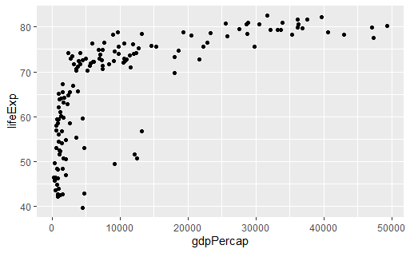

```r
dat %>%
    filter(gdpPercap<75000) %>%
    ggplot(aes(x = gdpPercap, y=lifeExp)) +
    geom_point()
```

This graph is boring, but we can improve it!

```r
dat %>%
    filter(gdpPercap<75000) %>%
    ggplot(aes(x = log(gdpPercap), y = lifeExp, size = pop, color = continent)) +
    geom_point(alpha = 0.7) +
    geom_smooth(method = lm, show.legend = FALSE) +
    scale_color_viridis_d() +
    theme_classic() +
    labs(title = "Life Expectancy and GDP Per Capita", y = "Life Expectancy in Years", x = "Natural Log of GDP per Capita")
```

[output not shown]

Or maybe we want to break these out on different graphs by continent:

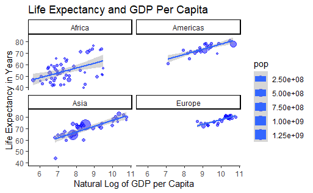

```r
dat %>%
    filter(gdpPercap<75000) %>%
    ggplot(aes(x = log(gdpPercap), y = lifeExp, size = pop)) +
    geom_point(color = "blue", alpha = 0.5) +
    geom_smooth(method = lm) +
    facet_wrap(~continent) +
    theme_classic() +
    labs(title = "Life Expectancy and GDP Per Capita", y = "Life Expectancy in Years", x = "Natural Log of GDP per Capita")
```

## Summing Up

R is extremely powerful, is the current state-of-the-art statistics/data analytics/data visualization software out there, and I hope this brief exercise piques your interest in learning more of how to use R.